## Instructions to execute the code, if needed:

1. Please modify the dataset file location in the cell 3 of this file, and also use the 3 files which are a split version of the original dataset, because there were uploading issues on CAC.

```python
# -*- coding: utf-8 -*-
import pandas as pd
import numpy as np

import nltk
nltk.download('stopwords')
from nltk.corpus import stopwords

import spacy
import gensim
import gensim.corpora as corpora
from gensim.models import CoherenceModel, TfidfModel, HdpModel
import pyLDAvis
import pyLDAvis.gensim  # don't skip this

from sklearn.decomposition import LatentDirichletAllocation
import sys
import re
```

```python
from yellowbrick.text import FreqDistVisualizer
from sklearn.feature_extraction.text import CountVectorizer
import matplotlib.pyplot as plt

import textblob
from gensim.parsing.preprocessing import stem_text
from nltk.stem import SnowballStemmer

import os
from gensim.models.wrappers import LdaMallet
#from gensim.models.doc2vec import Doc2Vec, TaggedDocument
#import multiprocessing
#cores = multiprocessing.cpu_count() #we ran it on 8 cores
#assert gensim.models.doc2vec.FAST_VERSION > -1, "This will be painfully slow otherwise"

from PIL import Image
from wordcloud import WordCloud, STOPWORDS

from sklearn.model_selection import train_test_split
```

```python
df_1 = pd.read_excel("C:/Users/Karandeep/Downloads/Natural Language Processing/Project/imdb_reviews_1.xlsx", encoding='utf-8')
df_2 = pd.read_excel("C:/Users/Karandeep/Downloads/Natural Language Processing/Project/imdb_reviews_2.xlsx", encoding='utf-8')
df_3 = pd.read_excel("C:/Users/Karandeep/Downloads/Natural Language Processing/Project/imdb_reviews_3.xlsx", encoding='utf-8')
df = pd.concat([df_1, df_2,df_3])
```

```python
pd.DataFrame(df).info()
```

```
<class 'pandas.core.frame.DataFrame'>
Int64Index: 48512 entries, 0 to 18248
Data columns (total 4 columns):
uid          48512 non-null int64
score        48512 non-null int64
sentiment    48512 non-null object
Review       48512 non-null object
dtypes: int64(2), object(2)
memory usage: 1.9+ MB
```

# We used str.replace() to check what junk characters were we getting, and stored them in a file

df_junk.to_csv("/global/project/queens-mma/shared/Osgoode/Scene Pr./Folder/Untitled Folder/Progress till now/junk_characs_observed.xlsx", index = False)

We got the below irrelavant characters/strings:

> Dates: 6/24/2007 Years: 1976, 1999, 1957-1965, 70', 80' Special characters : é, &, ñ, “ (é looks like French character but incorrectly parsed)

> HTML tags: < />

> Exclamations: !, ., ', ",

> String of exclamations: !!!!, !!, ...., "", -------, **

> Something that looked liked ratings: 2/10, 8.15, *1/2, **

> Percentages: 95%

> NUmbers/Numeric values: 105

> Dollar values: $10

> Brackets: (, (,

> Some strings like 11385|4|| which indicated that original data file had corrupted the records by including more than one record in a record

> French accentuated characters - We notice that the original Excel file had converted characters for French. eg. Ã© was found instead of an accentuated character, i.e. the Excel already had the UTF-8 representation Funky looking symbols generally come from: They result from interpreting bytes with an encoding that seems to fit (i.e. it doesn't crash) but really doesn't.

## Data Cleaning

```python
# Some reviews were concatenated(hidden) into other reviews which will give us wrong sense of topics, hence, we need to extract those reviews out
# and create separate entries for them

#Checking to see what's the max. ID number so that we can create indexes after it
max_id = df['uid'].max()
print(max_id)

# Finding and extracting reviews that are concatenated in other reviews
# Reference : https://stackoverflow.com/questions/29294017/extract-substring-from-string-in-dataframe
addnl_reviews_neg = []
for d in df['Review']:
    addnl_review = re.search(r'[|][0-9][|]negative[|].*',str(d)) #Scan through string looking for a match to the pattern, returning a match object, or None if no match was found."""
    if addnl_review != None:
        addnl_review = addnl_review.group(0)
        addnl_review = addnl_review[1:len(addnl_review)-1]
        addnl_reviews_neg.append(addnl_review)

addnl_reviews_pos = []
for d in df['Review']:
    addnl_review = re.search(r'[|][0-9][|]positive[|].*',str(d)) #Scan through string looking for a match to the pattern, returning a match object, or None if no match was found."""
    if addnl_review != None:
        addnl_review = addnl_review.group(0)
        addnl_review = addnl_review[1:len(addnl_review)-1]
        addnl_reviews_pos.append(addnl_review)

addnl_reviews = addnl_reviews_neg + addnl_reviews_pos
print("No. of hidden reviews found : " + str(len(addnl_reviews)))


df_addnl = pd.DataFrame()
labels = ['uid', 'score', 'sentiment', 'Review']
for rev in addnl_reviews:
    max_id += 1
    rev_var = rev.split('|', maxsplit = 2)
    dict = {'uid': max_id, 'score': rev_var[0], 'sentiment':rev_var[1], 'Review':rev_var[2]}
    df_addnl = df_addnl.append(dict, ignore_index = True)

df_addnl = df_addnl[['uid','score','sentiment','Review']]
df_addnl.set_index(df_addnl['uid'], inplace = True)
df = pd.concat([df,df_addnl], ignore_index = True)
df.reset_index(drop = True, inplace = True)
```

```
12499
No. of hidden reviews found : 612
```

```python
# Just backup the DataFrame in case we need it sometime later
df = df.iloc[:,3]
df_backup = df
```

## Simple Tokenization

```python
def simple_tokenize(document_set):
    for doc in document_set:
        yield [w for w in (gensim.utils.tokenize(str(doc), deacc=True))]

get_ipython().run_line_magic('time', 'tokenized_df = list(simple_tokenize(df))')

# Visualize cleansed and tokenized output
print(list(tokenized_df[0]))
```

```
Wall time: 35 s
['To', 'sum', 'this', 'movie', 'up', 'it', 'is', 'LaBute', 'carrying', 'his', 'sadism', 'over', 'into', 'the', 'realm', 'of', 'comedic', 'farce', 'The', 'predictable', 'result', 'is', 'that', 'he', 'is', 'constantly', 'stepping', 'on', 'all', 'the', 'jokes', 'by', 'insisting', 'on', 'surrounding', '…
```

## Data Exploration

```
The AVERAGE LENGTH of the reviews is: 245.2438726488071
```

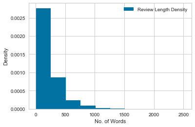

```python
#Count the average length of the reviews in terms of no. of tokens
review_length = []
for review in tokenized_df:
    review_length.append(len(review))

print("The AVERAGE LENGTH of the reviews is: " + str(np.mean(review_length)))

# Density distribution of review length
plt.hist(review_length, density = True, label = 'Review Length Density')
plt.xlabel('No. of Words')
plt.ylabel('Density')
plt.legend(loc='best')
plt.show()
```

```python
print("The MEDIAN LENGTH of the reviews is: " + str(np.median(review_length)))
```

```
The MEDIAN LENGTH of the reviews is: 179.0
```

```python
# ## Lemmatization - **Skipped for now because not getting satisfactory results
#
##Correcting spelling of words
#
#def spell_correct(document_set):
#    for doc in document_set:
##        doc_restitched = [" ".join(w) for w in doc]
#        yield textblob.TextBlob(str(doc)).correct()
#
#get_ipython().run_line_magic('time', 'spellchecked_df = list(spell_correct(tokenized_df))')
#
## Visualize cleansed and tokenized output
#print(list(spellchecked_df[0]))

# #Lemmatizing the processed words
# python -m spacy download en
# nlp = spacy.load('en', disable=['parser', 'ner'])
# def lemmatize(document_set, allowed_postags=['NOUN', 'ADJ', 'VERB', 'ADV']): #The English lemmatization data is taken from WordNet, as per SpaCy
#     final_list = []
#     for doc in document_set:
#         doc_v = nlp(" ".join(doc))
#         final_list.append([token.lemma_ for token in doc_v if token.pos_ in allowed_postags])
#     return final_list

# %time lemmatized_df = lemmatize(tokenized_df)

# #Visualize lemmatized output
# print(lemmatized_df[0])
# lemmatized_df_backup = lemmatized_df
```

## Data Cleansing/Preprocessing = Lowercase + Ignore tokens that are too long/short + Stopwords removal + Tokenization

```python
def lowercase_remove_stopwords_tokenize(document_set):
    stop_words = stopwords.words('english')
    stop_words.extend(['br','film','films','movie','movies','see','saw','watch','watched','watches','look','looks','looked'
#                      ,'accordingly','utmost','nt','seamlessly','passing','unwanted','invoke','panel','ita','external','offset','halt','exclude','working','perpetually','invariably','instrumental','san','perpetuate','huh','ram','esque','extension','revealing','log','probe','shtick','purposely','avail','sided','ie','entity','etc','used','standpoint','dot','underline','criterion','integral','handed','hamper','withdraw','marginally','browse','standing','minus','quip','temporary','compilation','uncompromising','familiarity','exceedingly','insignificant','willingly','lack_thereof','ash','tho','calculate','suited','saying','needlessly','veer','ax','since','drastically','sync','preferably','detach','ne','contend','sway','formerly','procedure','percent','underlying','requisite','requirement','sap','symbolize','behalf','aptly','peek','ed','anyways','wan','stem','potent','beforehand','gently','inclined','pm','flourish','array','infinitely','output','cease','ala','prime_example','serve_purpose','compound','ongoing','loosely_base','constitute','imo','organize','preparation','wherein','stance','btw','fundamental','allegedly','user_comment','rol','sincerely','casually','officially','means','extract','vice_versa','prevail','sample','anytime','anyhow','upcoming','adaption','verbal','precise','tightly','courtesy','spectator','occurrence','nutshell','pivotal','recur','consequently','talking','shockingly','wherever','valid','moviegoer','phase','comparable','thereby'
#                      ,'a','able','about','above','abst','accordance','according','accordingly','across','act','actually','added','adj','affected','affecting','affects','after','afterwards','again','against','ah','all','almost','alone','along','already','also','although','always','am','among','amongst','an','and','announce','another','any','anybody','anyhow','anymore','anyone','anything','anyway','anyways','anywhere','apparently','approximately','are','aren','arent','arise','around','as','aside','ask','asking','at','auth','available','away','awfully','b','back','be','became','because','become','becomes','becoming','been','before','beforehand','begin','beginning','beginnings','begins','behind','being','believe','below','beside','besides','between','beyond','biol','both','brief','briefly','but','by','c','ca','came','can','cannot','can\'t','cause','causes','certain','certainly','co','com','come','comes','contain','containing','contains','could','couldnt','d','date','did','didn\'t','different','do','does','doesn\'t','doing','done','don\'t','down','downwards','due','during','e','each','ed','edu','effect','eg','eight','eighty','either','else','elsewhere','end','ending','enough','especially','et','et-al','etc','even','ever','every','everybody','everyone','everything','everywhere','ex','except','f','far','few','ff','fifth','first','five','fix','followed','following','follows','for','former','formerly','forth','found','four','from','further','furthermore','g','gave','get','gets','getting','give','given','gives','giving','go','goes','gone','got','gotten','h','had','happens','hardly','has','hasn\'t','have','haven\'t','having','he','hed','hence','her','here','hereafter','hereby','herein','heres','hereupon','hers','herself','hes','hi','hid','him','himself','his','hither','home','how','howbeit','however','hundred','i','id','ie','if','i\'ll','im','immediate','immediately','importance','important','in','inc','indeed','index','information','instead','into','invention','inward','is','isn\'t','it','itd','it\'ll','its','itself','i\'ve','j','just','k','keep','keeps','kept','kg','km','know','known','knows','l','largely','last','lately','later','latter','latterly','least','less','lest','let','lets','like','liked','likely','line','little','\'ll','look','looking','looks','ltd','m','made','mainly','make','makes','many','may','maybe','me','mean','means','meantime','meanwhile','merely','mg','might','million','miss','ml','more','moreover','most','mostly','mr','mrs','much','mug','must','my','myself','n','na','name','namely','nay','nd','near','nearly','necessarily','necessary','need','needs','neither','never','nevertheless','new','next','nine','ninety','no','nobody','non','none','nonetheless','noone','nor','normally','nos','not','noted','nothing','now','nowhere','o','obtain','obtained','obviously','of','off','often','oh','ok','okay','old','omitted','on','once','one','ones','only','onto','or','ord','other','others','otherwise','ought','our','ours','ourselves','out','outside','over','overall','owing','own','p','page','pages','part','particular','particularly','past','per','perhaps','placed','please','plus','poorly','possible','possibly','potentially','pp','predominantly','present','previously','primarily','probably','promptly','proud','provides','put','q','que','quickly','quite','qv','r','ran','rather','rd','re','readily','really','recent','recently','ref','refs','regarding','regardless','regards','related','relatively','research','respectively','resulted','resulting','results','right','run','s','said','same','saw','say','saying','says','sec','section','see','seeing','seem','seemed','seeming','seems','seen','self','selves','sent','seven','several','shall','she','shed','she\'ll','shes','should','shouldn\'t','show','showed','shown','showns','shows','significant','significantly','similar','similarly','since','six','slightly','so','some','somebody','somehow','someone','somethan','something','sometime','sometimes','somewhat','somewhere','soon','sorry','specifically','specified','specify','specifying','still','stop','strongly','sub','substantially','successfully','such','sufficiently','suggest','sup','sure','t','take','taken','taking','tell','tends','th','than','thank','thanks','thanx','that','that\'ll','thats','that\'ve','the','their','theirs','them','themselves','then','thence','there','thereafter','thereby','thered','therefore','therein','there\'ll','thereof','therere','theres','thereto','thereupon','there\'ve','these','they','theyd','they\'ll','theyre','they\'ve','think','this','those','thou','though','thoughh','thousand','throug','through','throughout','thru','thus','til','tip','to','together','too','took','toward','towards','tried','tries','truly','try','trying','ts','twice','two','u','un','under','unfortunately','unless','unlike','unlikely','until','unto','up','upon','ups','us','use','used','useful','usefully','usefulness','uses','using','usually','v','value','various','\'ve','very','via','viz','vol','vols','vs','w','want','wants','was','wasnt','way','we','wed','welcome','we\'ll','went','were','werent','we\'ve','what','whatever','what\'ll','whats','when','whence','whenever','where','whereafter','whereas','whereby','wherein','wheres','whereupon','wherever','whether','which','while','whim','whither','who','whod','whoever','whole','who\'ll','whom','whomever','whos','whose','why','widely','willing','wish','with','within','without','wont','words','world','would','wouldnt','www','x','y','yes','yet','you','youd','you\'ll','your','youre','yours','yourself','yourselves','you\'ve','z','zero'
#                      ,'occur','equally','count','assume','intend','depict','cinematic','month','expectation','display','personally','purpose','regard','literally','tone','step','setting','entirely','share','imdb','amount','exist','apart','term','fairly','pace','general','stage','total','highly','rate','choice','premise','subject','eventually','whatev','notice','actual','describe','plan','continue','choose','detail','capture','send','clear','develop','clearly','major','remain','fill','focus','basically','produce','provide','allow','explain','check','note','exactly','ago','event','order','number','situation','theme','complete','level','feeling','chance','today','stay','genre','realize','speak','portray','matter','throw','learn','manage','totally','entire','example','comment','review','picture','mention','finally','consider','full','absolutely','sit','guess','definitely','feature','base','sort','wonder','involve','view','suppose','word','add','rest','appear','simply','viewer','remember','talk','understand','piece','include','second','sound','hour','hear','follow','true','main','sense','move','bring','read','course','expect','screen','call','reason','bit','write','set','happen','minute','leave','lot','feel','year','find','thing','well','people','time','pron'
#               ,'apply','strangely','transform','insist','exact','properly','advance','contribute','overcome','exploit','determine','initially','pay_attention','relative','emerge','consequence','description','effectively','interpretation','visually','directly','correct','define','thankfully','link','interaction','accidentally','semi','possibility','virtually','majority','worthwhile','hopefully','glimpse','accompany','identify','argue','understanding','associate','source','segment','maintain','pre','remove','possess','scenario','rely','reflect','par','discuss','context','gain','revolve','progress','unable','insight','kinda','noir','improve','resemble','genuinely','separate','grab','advice','consist','originally','aim','constant','establish','perspective','viewing','test','technique','aware','current','prepare','intention','lay','affect','responsible','unnecessary','rid','conversation','connect','range','demand','utter','belong','prefer','mid','unknown','apparent','convey','watchable','comparison','generation','central','damn','surround','rarely','wise','connection','explanation','favourite','whatsoever','industry','absolute','earlier','grade','english','thoroughly','fellow','recognize','loose','influence','explore','ready','ahead','individual','addition','worthy'
               ])# Defining list of stopwords to use
    for doc in document_set:
        yield [w for w in (gensim.utils.simple_preprocess(str(doc), deacc=True, min_len = 3)) if w not in stop_words]
# simple_preprocess() - Converts a document into a list of lowercase tokens, ignoring tokens that are too short or too long.
# deacc=True deaccents and removes punctuations
# yield statement makes sure that a 'Generator object' is returned, and does not start execution of iteration immediately

#Some stopwords taken from:
# http://xpo6.com/list-of-english-stop-words/
# https://www.ranks.nl/stopwords

#lowercase_remove_stopwords_tokenize returns a generator object, and using list() causes it to apply the generator on the data df
get_ipython().run_line_magic('time', 'tokenized_df = list(lowercase_remove_stopwords_tokenize(tokenized_df))')

# Visualize cleansed and tokenized output
print(list(tokenized_df[0]))
```

```
Wall time: 1min 15s
['sum', 'labute', 'carrying', 'sadism', 'realm', 'comedic', 'farce', 'predictable', 'result', 'constantly', 'stepping', 'jokes', 'insisting', 'surrounding', 'blood', 'curdling', 'violence', 'extremely', 'hateful', 'characters', 'also', 'evidence', 'continuing', 'efforts', 'insult', 'ridicule', 'ever…
```

## Stemming

```python
#We tried with all the below stemmers  but snowball gave us best results
def snowball_stemming(document_set):
    snowball = nltk.stem.SnowballStemmer('english')
    for doc in document_set:
        yield [snowball.stem(w) for w in doc]

def porter_stemming(document_set):
    porter = nltk.stem.PorterStemmer(mode='NLTK_EXTENSIONS')
    for doc in document_set:
        yield [porter.stem(w) for w in doc]

def lancaster_stemming(document_set):
    lancaster = nltk.stem.LancasterStemmer()
    for doc in document_set:
        yield [lancaster.stem(w) for w in doc]

get_ipython().run_line_magic('time', 'stemmed_df = list(snowball_stemming(tokenized_df))')

# Visualize cleansed and tokenized output
print(list(stemmed_df[0]))
```

```
Wall time: 1min 49s
['sum', 'labut', 'carri', 'sadism', 'realm', 'comed', 'farc', 'predict', 'result', 'constant', 'step', 'joke', 'insist', 'surround', 'blood', 'curdl', 'violenc', 'extrem', 'hate', 'charact', 'also', 'evid', 'continu', 'effort', 'insult', 'ridicul', 'everyth', 'sight', 'apolog', 'weak', 'gestur', 'ba…
```

## Bi-grams

```python
#Using gensim's 'Phrases' class functions
def bi_grams(document_set):
        bi_gram_mod = gensim.models.Phrases(document_set, min_count=5, threshold=100) #the bigram should appear min min_count times in the corpus
        return bi_gram_mod
        #Phraser is a wrapper that is faster compared to the Phrases class, but we decided not to use it

get_ipython().run_line_magic('time', 'bi_grams_df = bi_grams(stemmed_df)[stemmed_df]')

# Visualize bigram output
print(bi_grams_df[0])
```

```
Wall time: 13.5 s
['sum', 'labut', 'carri', 'sadism', 'realm', 'comed', 'farc', 'predict', 'result', 'constant', 'step', 'joke', 'insist', 'surround', 'blood_curdl', 'violenc', 'extrem', 'hate', 'charact', 'also', 'evid', 'continu', 'effort', 'insult', 'ridicul', 'everyth', 'sight', 'apolog', 'weak', 'gestur', 'basic…
```

## Tri-grams

```python
#Assumption - The output of bi_grams function would be passed to this function as an input
def tri_grams(document_set):
        tri_gram_mod = gensim.models.Phrases(document_set, min_count=3, threshold=100) #the trigram should appear min min_count times in the corpus
        return tri_gram_mod
        #Phraser is a wrapper that is faster compared to the Phrases class, but we decided not to use it

get_ipython().run_line_magic('time', 'tri_grams_df = tri_grams(bi_grams_df)[bi_grams_df] #Notice how bi_grams_df was given as an input')

# Visualize trigram output
print(tri_grams_df[0])
```

```
Wall time: 44.9 s
['sum', 'labut', 'carri', 'sadism', 'realm', 'comed', 'farc', 'predict', 'result', 'constant', 'step', 'joke', 'insist', 'surround', 'blood_curdl', 'violenc', 'extrem', 'hate', 'charact', 'also', 'evid', 'continu', 'effort', 'insult', 'ridicul', 'everyth', 'sight', 'apolog', 'weak', 'gestur', 'basic…
```

## Custom Stopwords removal (after many Iterations)

```python
def remove_stopwords(document_set):
    stop_words_x = ['find', 'back', 'another', 'becom','sinc','later','includ','away','use','feel','may','howev','enough','see','might','found',
                    'effect','viewer','let','also','much','mani','seem','give','though','done','must','make','made','get', 'realli','would','even','way','peopl','think','made','know','thing','could',
                    'say','come','still','part','want','tri','actual','especi','around','version','keep','soon','check','eventu','lot','exampl','exact','realiz','describ','refer','serv','edg','assum','seen','ever','agre','prefer','vari','rate','came','piec','deserv','aw','asid','toward','imdb','yeah','alway','sure','par','apart','genr','situat','provid','explan'
                    'around','later','goe','portray','open','came','became','alreadi','ask','return','wait','continu',
                    'anoth','believ','bit','thought', 'pretti','take','never', 'watch','everi','got','point','fact','without','need','person','almost','yet','tell','line','kind','whole','course','expect','probabl','main','less','sort','cut','pick','rememb','often','throughout','number','attempt','near','cannot','gave',
                    'anyway','across','becam','help','follow','look','said','other','topic','somebodi','sat','everyon','easili','listen','reach','alter','truli','went','side','knew','subject','otherwis','affect','belong','intent','improv','angle','talki','hey','pleas','add'
                    'time','someth','noth','place','put','although','moment','anyth','happen','view','cours','far','reason','name','well','rather','complet','appear','gener','creat','along','featur','differ','understand','bring','word','comment','sometim','next','possibl','theme','anyon','simpli','imagin','abl','talk','heard','notic','inde','remind','occur','convey','establish','compel','neg','capabl','due','prove','mostli','regard','discuss','onto','moreov','relat','unfold','convinc','beyond','consist','essenti','instanc','damn','anymor','insist','frankli','manner','conduct','spoke','compris','familiar','kept','necessari','descript',
                    'day','right','leave','felt','learn','manag','captur','full','simpl','known','shown','form','whose','audienc','present','remain','hear','somoewhat','self','rel','latter','angl','consider','earlier','enter','among','inform','constantli','evid','seek','meant','observ','intend','question','type','process','sourc','chose','thank','highlight','pre',
                    'two','focus','geniu','supposedli','deepli','hardli','pure','furthermor','somewher','first','last','one','non','pass','certain','time','valu','review','today','gone','score','began','mayb','yes','either','mention','recal','express','numer','thorough','non','certain','true','remark','encount', 'experi','time','valu','review','today','gone','score','began','mayb','yes','either','mention','numer','nobodi','ampl',
                    'understood','mere','contain','random','choic','interpret','attent',
                    'besid','idea','cant','can','skip','dude','guess','overal','core','kinda'
                    'potenti','wonder','rest','year','mix','hour','six',
                    'somewhat','three','display','prepar','stuff','certainli'
                    'year_ago','insid','despit','neither','step']
    for doc in document_set:
        yield [w for w in (gensim.utils.simple_preprocess(str(doc), deacc=True, min_len = 3)) if w not in stop_words_x]

#lowercase_remove_stopwords_tokenize returns a generator object, and using list() causes it to apply the generator on the data df
get_ipython().run_line_magic('time', 'tri_grams_df_2= list(remove_stopwords(tri_grams_df))')

# Visualize cleansed and tokenized output
print(list(tri_grams_df_2[0]))
```

```
Wall time: 1min 59s
['sum', 'labut', 'carri', 'sadism', 'realm', 'comed', 'farc', 'predict', 'result', 'constant', 'joke', 'surround', 'blood_curdl', 'violenc', 'extrem', 'hate', 'charact', 'effort', 'insult', 'ridicul', 'everyth', 'sight', 'apolog', 'weak', 'gestur', 'basic', 'work', 'plot', 'contriv', 'charact', 'dim…
```

## Some exploratory stuff

```
The AVERAGE LENGTH of the reviews after all pre-processing is: 78.53016855304942
```

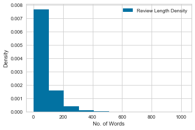

```python
#Count the average length of the reviews in terms of no. of tokens
review_length = []
for review in tri_grams_df_2:
    review_length.append(len(review))

print("The AVERAGE LENGTH of the reviews after all pre-processing is: " + str(np.mean(review_length)))

# Density distribution of review length
plt.hist(review_length, density = True, label = 'Review Length Density')
plt.legend(loc='best')
plt.xlabel('No. of Words')
plt.ylabel('Density')
plt.show()
```

## Experimenting with Doc2Vec

***Skipped, because the training was too slow, and results were of poor quality

```python
#Trying out Gensim Doc2Vec

#First Approach = PV-DM (Paragraph Vector - Distributed Memory)
# Distributed Memory model preserves the word order in a document
#Need tagged documents first
#tagged_docs = [TaggedDocument(words=d, tags=[str(i)]) for i, d in enumerate(tri_grams_df)]
#max_epochs = 100
#model = Doc2Vec(vector_size=50,
#                alpha=0.025,
#                min_alpha=0.00025,
#                min_count=5,
#                dm =1) # dm = 1 means PV-DM
#vocab = model.build_vocab(tagged_docs)
#for epoch in range(max_epochs):
#    print('iteration {0}'.format(epoch))
#    model.train(tagged_docs,
#                total_examples=model.corpus_count,
#                epochs=model.epochs)
#    # decrease the learning rate
#    model.alpha -= 0.0002
#    # fix the learning rate, no decay
#    model.min_alpha = model.alpha
#
#model.save("Doc2Vec_1.model")
#print("Saved successfully!")

#  model.wv.get_vector('chris_rock') - can be used to get the word embedding vector of n_dim = 50 for the particular word
# model.wv.index2entity - gives you the word names at the particular index. Returns a list
# model.docvecs.save_word2vec_format('C:/Users/Karandeep/Downloads/Natural Language Processing/Project/abc.csv', prefix='doc', fvocab=None, total_vec=None, binary=False, write_first_line=True) - downloads the embeddings for docs

#vectors = list(model.docvecs.vectors_docs)
#from sklearn.cluster import KMeans
#from sklearn import metrics
#kmeans = KMeans(n_clusters=10)
#kmeans.fit(vectors)
#labels = kmeans.labels_
#centroids = kmeans.cluster_centers_
#
#print ("Cluster labels:")
#print (labels)
#print ("Centroids:")
#print (centroids)
#
#print ("Score (Opposite of the value of X on the K-means objective which is Sum of distances of samples to their closest cluster center):")
#print (kmeans.score(vectors))
#
#silhouette_score = metrics.silhouette_score(vectors, labels, metric='euclidean')
#
#print ("Silhouette_score: ")
#print (silhouette_score)

#get_ipython().run_line_magic('matplotlib', 'inline')
#vis = pyLDAvis.gensim.prepare(topic_model=model, corpus=vectors, dictionary=list(model.vocabulary))
#pyLDAvis.enable_notebook()
#pyLDAvis.display(vis)


#Second Approach = PV-DBOW (Paragraph Vector - Distributed BoW)
# BoW model DOES NOT preserve the word order in a document
#max_epochs = 10
#model = Doc2Vec(vector_size=20,
#                alpha=0.025,
#                min_alpha=0.00025,
#                min_count=1,
#                dm =0) # dm = 0 means PV-DBOW
#model.build_vocab(tagged_docs)
#for epoch in rangfe(max_epochs):
#    print('iteration {0}'.format(epoch))
#    model.train(tagged_docs,
#                total_examples=model.corpus_count,
#                epochs=model.iter)
#    # decrease the learning rate
#    model.alpha -= 0.0002
#    # fix the learning rate, no decay
#    model.min_alpha = model.alpha
#
#model.save("Doc2Vec_1.model")
#print("Saved successfully!")
```

## Building the Dictionary (Index:Word) for the words

```python
id2word_lda = gensim.corpora.Dictionary(tri_grams_df_2) #The keyword 'Dictionary' makes an index:word dictionary of the corpus
print(len(id2word_lda))
```

```
84616
```

```python
# Downloading the [Words: Count in all Docs.] for all tokens in the corpus
dict1 = id2word_lda.token2id # token - id
dict2 = id2word_lda.dfs # id - count
list_word_freq = [[token, dict2[id]] for token, id in dict1.items()]
# pd.DataFrame(list_word_freq).to_excel("C:/Users/Karandeep/Downloads/Natural Language Processing/Project/words_vocab.xlsx", header = False, index = False)
```

```python
list_word_freq
```

[output not shown]

[output cut: 946 more lines]

```
 ['crude', 336],
 ['download', 88],
 ['exorcist', 117],
 ['guy', 6235],
 ['happi', 1856],
 ['horribl', 2472],
 ['humor', 2681],
 ['jami_kennedi', 21],
 ['jim_carrey', 117],
 ['loki', 9],
 ['mask', 461],
 ['mistak', 1065],
 ['nose', 330],
 ['pay_attent', 269],
 ...]
```

## Filter super-rare and super-frequent words

We are just displaying our best iteration here, although we tried with many iterations

```python
id2word_lda.filter_extremes(no_below=15, no_above=0.85, keep_n=100000) #
print(len(id2word_lda))
```

```
14706
```

## Build Corpus for BoW model using the dictionary we created

```python
# Term document frequency =; Bag of words representation
corpus_lda = [id2word_lda.doc2bow(doc) for doc in tri_grams_df_2]
print(corpus_lda[0])
```

```
[(0, 1), (1, 1), (2, 1), (3, 1), (4, 1), (5, 3), (6, 1), (7, 2), (8, 1), (9, 1), (10, 1), (11, 1), (12, 1), (13, 1), (14, 1), (15, 1), (16, 1), (17, 1), (18, 1), (19, 1), (20, 1), (21, 1), (22, 1), (23, 1), (24, 1), (25, 1), (26, 1), (27, 1), (28, 1), (29, 1), (30, 1), (31, 1), (32, 1), (33, 1), (34…
```

## Build Corpus for TF-IDF model using the dictionary we created

```python
tfidf = TfidfModel(corpus_lda)
corpus_lda_tfidf = tfidf[corpus_lda]
```

## Elbow plots to get num_topics

```
5
Coherence:0.34960741366677983
Perplexity:3211.334878221717
10
Coherence:0.3349193783995932
Perplexity:4938.0724326087175
15
Coherence:0.2843839496565675
Perplexity:489579.044788867
20
Coherence:0.24680439531606546
Perplexity:2255945.31422884
25
Coherence:0.2679077965022226
Perplexity:9688633.40939979
```

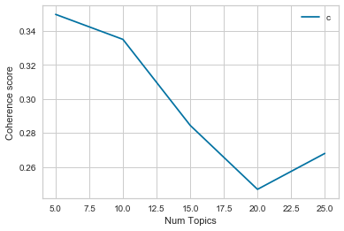

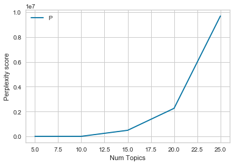

```python
coherence_values = []
model_list = []
perplexities = []
#Atleast 10 topics - business rule
for num_topics in range(5, 30, 5):
   print(num_topics)
   lda_mod=gensim.models.ldamodel.LdaModel(corpus=corpus_lda,id2word=id2word_lda, num_topics = num_topics, distributed = False, random_state=1234, update_every=1, chunksize=100, passes=10, iterations=100, alpha='auto')
   model_list.append(lda_mod)
   coherence_model_lda = CoherenceModel(model=lda_mod, texts=tri_grams_df_2, dictionary=id2word_lda, coherence='c_v')
   coherence = coherence_model_lda.get_coherence()
   print("Coherence:" + str(coherence))
   coherence_values.append(coherence)
   perplexity = np.exp(-1. * lda_mod.log_perplexity(corpus_lda))
   print("Perplexity:" + str(perplexity))
   perplexities.append(perplexity)

x = range(5, 30, 5)
plt.plot(x, coherence_values)
plt.xlabel("Num Topics")
plt.ylabel("Coherence score")
plt.legend(("coherence_values"), loc='best')
plt.show()

x = range(5, 30, 5)
plt.plot(x, perplexities)
plt.xlabel("Num Topics")
plt.ylabel("Perplexity score")
plt.legend(("Perplexity_values"), loc='best')
plt.show()
```

## LDA model

> Displaying only the best iteration below to provide a crisp review.

# The multicore implementation 'gensim.models.ldamulticore' did not run, so we had to use the single core gensim.models.ldamodel.LdaModel

```python
num_topics = 15
%time lda_mod=gensim.models.ldamodel.LdaModel(corpus=corpus_lda,id2word=id2word_lda, num_topics = num_topics, distributed = False, random_state=1234, update_every=1, chunksize=100, passes=10, iterations=100, alpha='auto')
```

```
Wall time: 5min 34s
```

## Printing Topics from our Model

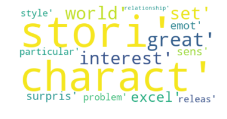

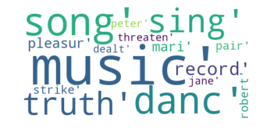

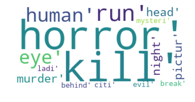

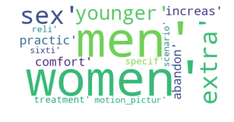

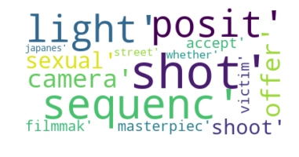

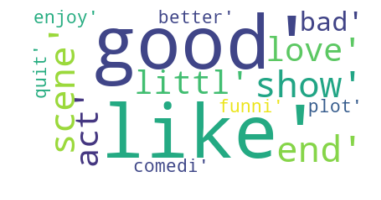

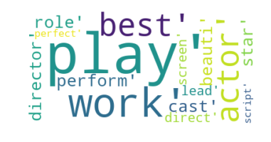

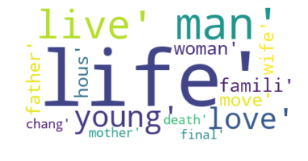

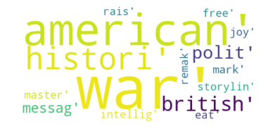

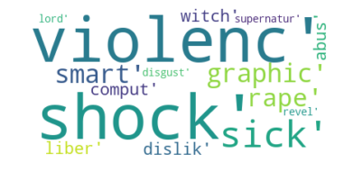

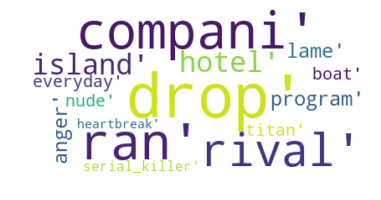

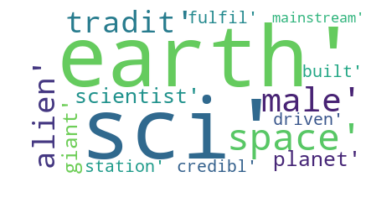

[3 more figures not shown]

```python
#Code to print topics from: https://www.scrapehero.com/how-to-analyse-product-reviews-using-lda-topic-modelling/ as this is standard code
word_dict = {};
for i in range(num_topics):
    words = lda_mod.show_topic(i, topn = 15)
    wc = WordCloud(background_color="white", max_words=20,
               contour_width=4, contour_color='steelblue')
    wc.generate(str(lda_mod.show_topic(i, topn = 15)))
    plt.imshow(wc, interpolation='bilinear')
    plt.axis("off")
    plt.show()
```

## Calculate no-fold Perplexity and Coherence to get a good idea

```python
# lda_mod.save("C:/Users/Karandeep/Downloads/Natural Language Processing/Project/LDA_model_saved")
print('Perplexity of this Topic model is: ', np.exp(-1. * lda_mod.log_perplexity(corpus_lda))) #The lower the better

coherence_model_lda = CoherenceModel(model=lda_mod, texts=tri_grams_df_2, dictionary=id2word_lda, coherence='c_v') #Higher the better
coherence_lda = coherence_model_lda.get_coherence()
print('Coherence Score of this Topic model is: ', coherence_lda)
```

```
Perplexity of this Topic model is:  489579.0430825376
Coherence Score of this Topic model is:  0.2843839496565675
```

## Calculate 10-fold Cross Validation Perplexity and Coherence to get a good idea

```python
# Code from: https://machinelearningmastery.com/implement-resampling-methods-scratch-python/
from random import seed
from random import randrange
# Split a dataset into k folds
def cross_validation_split(dataset, folds=10):
    dataset_split = list()
    dataset_copy = list(dataset)
    fold_size = int(len(dataset) / folds)
    for i in range(folds):
        fold = list()
        while len(fold) < fold_size:
            index = randrange(len(dataset_copy))
            fold.append(dataset_copy.pop(index))
        dataset_split.append(fold)
    return dataset_split

# test cross validation split
seed(1)
folds = cross_validation_split(tri_grams_df_2, 10)
```

```python
# Gensim did not allow to use a cross_val_score or cross_validate function on the NLP data, so we built custom logic
# for Cross Validation
k=10
num_topics = 15
sum_training_coherence = 0
sum_training_perplexity = 0
sum_test_perplexity = 0
sum_test_coherence = 0
sum_coherence, sum_perplexity = 0, 0
for i in range(k): #Custom logic for scratch implementation fo k-fold CV
    cv_slot1 = i
    cv_slot2 = i+1
    if cv_slot2 == k:
       cv_slot2 = 0
    print(cv_slot1)
    print(cv_slot2)

    tri_grams_df_2_test = folds[i]
    tri_grams_df_2_train = []
    for j in range(k):
        if j!=i:
            tri_grams_df_2_train.extend(folds[j])


    id2word_lda = gensim.corpora.Dictionary(tri_grams_df_2)
    id2word_lda.filter_extremes(no_below=15, no_above=0.85, keep_n=100000) #

    corpus_lda_train = [id2word_lda.doc2bow(doc) for doc in tri_grams_df_2_train]
    corpus_lda_test = [id2word_lda.doc2bow(doc) for doc in tri_grams_df_2_test]

    lda_mod=gensim.models.ldamodel.LdaModel(corpus=corpus_lda_train,id2word=id2word_lda, num_topics = num_topics, distributed = False, random_state=1234, update_every=1, chunksize=100, passes=10, iterations=100, alpha='auto')
    train_coherence = CoherenceModel(model=lda_mod, corpus=corpus_lda_train, dictionary=id2word_lda, coherence='u_mass').get_coherence()
    test_coherence = CoherenceModel(model=lda_mod, corpus = corpus_lda_test, dictionary=id2word_lda, coherence='u_mass').get_coherence()
    print("Training Coherence for iteration" + str(i) + "is: " + str(train_coherence))
    print("Test Coherence for iteration" + str(i) + "is: " + str(test_coherence))

    train_perplexity = np.exp(-1. * lda_mod.log_perplexity(corpus_lda_train))
    print("Training Perplexity for iteration" + str(i) + "is: " + str(train_perplexity))
    test_perplexity = np.exp(-1. * lda_mod.log_perplexity(corpus_lda_test))
    print("Test Perplexity for iteration" + str(i) + "is: " + str(test_perplexity))

    sum_training_coherence += train_coherence
    sum_training_perplexity += train_perplexity
    sum_test_coherence += test_coherence
    sum_test_perplexity += test_perplexity
print('Mean Training Coherence after k-fold CV: ' + str(sum_training_coherence/k))
print('Mean Training Perplexity after k-fold CV: ' + str(sum_training_perplexity/k))
print('Mean Test Coherence after k-fold CV: ' + str(sum_test_coherence/k))
print('Mean Test Perplexity after k-fold CV: ' + str(sum_test_perplexity/k))
```

```
0
1
Training Coherence for iteration0is: -3.1447080153307225
Test Coherence for iteration0is: -4.9900931281580005
Training Perplexity for iteration0is: 207780.58434294237
Test Perplexity for iteration0is: 247223.12728568434
1
2
Training Coherence for iteration1is: -3.3299503168993363
Test Coherence for iteration1is: -5.178476214208923
Training Perplexity for iteration1is: 529543.922725133
Test Perplexity for iteration1is: 646832.3042456205
2
3
Training Coherence for iteration2is: -3.338513133845517
Test Coherence for iteration2is: -4.976242572001729
Training Perplexity for iteration2is: 527788.5868451
Test Perplexity for iteration2is: 660819.4749407523
3
4
Training Coherence for iteration3is: -3.3091677754057094
Test Coherence for iteration3is: -5.438813690864033
Training Perplexity for iteration3is: 529009.9398066521
Test Perplexity for iteration3is: 641585.8692406672
4
5
Training Coherence for iteration4is: -3.3190022042534566
Test Coherence for iteration4is: -5.385465443470774
Training Perplexity for iteration4is: 529607.1589789259
Test Perplexity for iteration4is: 649422.5838367974
5
6
Training Coherence for iteration5is: -3.3360103600901025
Test Coherence for iteration5is: -5.369331409438728
Training Perplexity for iteration5is: 532160.8736565256
Test Perplexity for iteration5is: 622678.8139944032
6
7
Training Coherence for iteration6is: -3.3455653033620703
Test Coherence for iteration6is: -5.125678648213747
```

[output cut: 9 more lines]

```
9
Training Coherence for iteration8is: -3.335645309574773
Test Coherence for iteration8is: -5.244407271134472
Training Perplexity for iteration8is: 527169.9949873188
Test Perplexity for iteration8is: 663243.9017411639
9
0
Training Coherence for iteration9is: -3.359494899566604
Test Coherence for iteration9is: -5.206939927888279
Training Perplexity for iteration9is: 532941.2227283443
Test Perplexity for iteration9is: 641688.0252957213
Mean Training Coherence after k-fold CV: -3.3136724610413553
Mean Training Perplexity after k-fold CV: 497406.2655286408
Mean Test Coherence after k-fold CV: -5.199925968517533
Mean Test Perplexity after k-fold CV: 606765.9913848836
```

## TF-IDF based model

Didn't give us good human interpretable topics and took more time

```python
%time get_ipython().run_line_magic('time', "lda_mod_tfidf = gensim.models.ldamodel.LdaModel(corpus=corpus_lda_tfidf,id2word=id2word_lda, num_topics=num_topics, distributed = False, random_state=56, update_every=1, chunksize=100, passes=50,iterations = 100, alpha='auto', per_word_topics=False)")
```

```
Wall time: 31min 51s
Wall time: 31min 51s
```

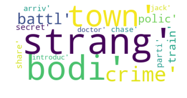

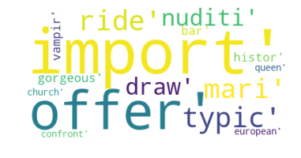

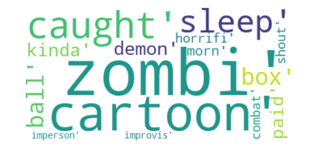

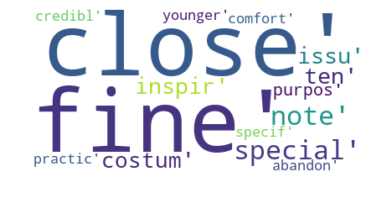

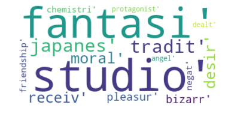

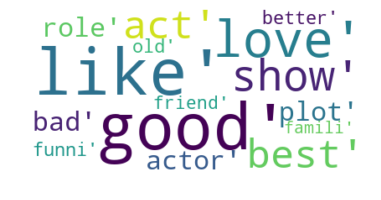

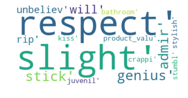

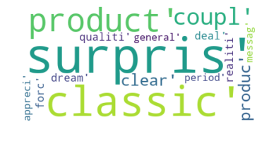

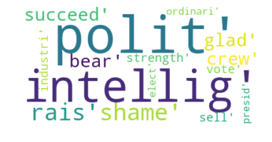

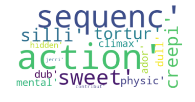

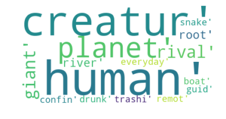

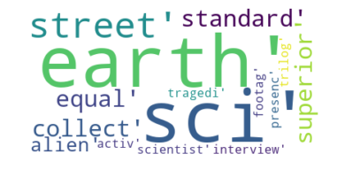

```python
#Code to print topics from: https://www.scrapehero.com/how-to-analyse-product-reviews-using-lda-topic-modelling/ as this is standard code
word_dict = {};
for i in range(num_topics):
    words = lda_mod_tfidf.show_topic(i, topn = 15)
    wc = WordCloud(background_color="white", max_words=20,
               contour_width=4, contour_color='steelblue')
    wc.generate(str(lda_mod.show_topic(i, topn = 15)))
    plt.imshow(wc, interpolation='bilinear')
    plt.axis("off")
    plt.show()
```

## LDA-HDP model

```python
%time get_ipython().run_line_magic('time', 'lda_hdp_mod_tfidf = gensim.models.HdpModel(corpus=corpus_lda_tfidf,id2word=id2word_lda)')
topics = lda_hdp_mod_tfidf.print_topics(num_topics=10, num_words=10)
for topic in topics:
    print(topic)
doc_lda_hdp_tfidf = lda_hdp_mod_tfidf[corpus_lda_tfidf]
```

```
Wall time: 1min 57s
Wall time: 1min 57s
(0, '0.001*great + 0.001*end + 0.001*like + 0.001*show + 0.000*graphic + 0.000*charact + 0.000*good + 0.000*tast + 0.000*stori + 0.000*hell')
(1, '0.001*charact + 0.001*great + 0.001*like + 0.000*laugh + 0.000*show + 0.000*bogart + 0.000*play + 0.000*bad + 0.000*hous + 0.000*good')
(2, '0.001*miss + 0.001*like + 0.000*factori + 0.000*solv_crime + 0.000*great + 0.000*stupid + 0.000*good + 0.000*duti + 0.000*surefir + 0.000*kid')
(3, '0.001*sought + 0.001*good + 0.001*better + 0.001*show + 0.000*slow_motion + 0.000*father + 0.000*nag + 0.000*sink_teeth + 0.000*like + 0.000*digress')
(4, '0.001*stori + 0.001*leav + 0.001*good + 0.001*complement + 0.001*least + 0.001*scene + 0.000*arnold + 0.000*bad + 0.000*like + 0.000*lifeless')
(5, '0.001*charact + 0.001*atlant + 0.001*viril + 0.001*stori + 0.001*london + 0.001*script + 0.001*canva + 0.001*john_malkovich + 0.000*chagrin + 0.000*better')
(6, '0.001*sam_lee + 0.001*guy + 0.001*sting + 0.001*docil + 0.001*charact + 0.000*taught + 0.000*good + 0.000*stori + 0.000*great + 0.000*friend')
(7, '0.001*like + 0.001*samurai + 0.001*femal + 0.001*scene + 0.001*granddaught + 0.001*bad + 0.001*english + 0.001*worst + 0.001*video + 0.001*show')
(8, '0.001*lex_luthor + 0.001*trick + 0.001*show + 0.000*bad + 0.000*left + 0.000*good + 0.000*stori + 0.000*involv + 0.000*scene + 0.000*kitschi')
(9, '0.001*hillbilli + 0.001*jennif_connelli + 0.001*super + 0.001*love + 0.001*whack + 0.001*heart_wrench + 0.000*portugues + 0.000*maud + 0.000*cast + 0.000*charact')
```

## Exporting PyLDAvis visualization

```python
#Exporting only for our best model, as compute resuources were limited on this machine
lda_model = lda_mod
corpus = corpus_lda
dictionary = id2word_lda

get_ipython().run_line_magic('matplotlib', 'inline')
vis = pyLDAvis.gensim.prepare(topic_model=lda_model, corpus=corpus, dictionary=dictionary)
pyLDAvis.save_html(vis,"C:/Users/Karandeep/Downloads/Natural Language Processing/Project/PyLDAvis_Feb23.html")
pyLDAvis.display(vis)
```

## References:

```python
# https://stackoverflow.com/questions/29294017/extract-substring-from-string-in-dataframe
# https://stackoverflow.com/questions/52518280/python-typeerror-float-object-is-not-iterable
# https://www.machinelearningplus.com/nlp/lemmatization-examples-python/
# https://medium.com/nanonets/topic-modeling-with-lsa-psla-lda-and-lda2vec-555ff65b0b05
# https://radimrehurek.com/gensim/utils.html
# https://www.machinelearningplus.com/nlp/topic-modeling-gensim-python/
# https://spacy.io/api/annotation
# GitHub of Prof. Stephen Thomas (Queen's University): Yellowbricks visualization for data exploration (exercise_topicmodelling.ipynb file)
# https://radimrehurek.com/gensim/models/ldamulticore.html#module-gensim.models.ldamulticore
# https://towardsdatascience.com/topic-modeling-and-latent-dirichlet-allocation-in-python-9bf156893c24
# https://bytes.com/topic/python/answers/462065-how-do-inner-join-dictionaries
# https://www.ranks.nl/stopwords
# Snowball stemmer: https://stackoverflow.com/questions/24647400/what-is-the-best-stemming-method-in-python
# Word2Vec https://towardsdatascience.com/automatic-topic-clustering-using-doc2vec-e1cea88449c
# Word2Vec Gensim: https://github.com/RaRe-Technologies/gensim/blob/develop/docs/notebooks/doc2vec-IMDB.ipynb
# https://medium.com/@mishra.thedeepak/doc2vec-simple-implementation-example-df2afbbfbad5
# Word2Vec Clustering: https://www.kaggle.com/nmud19/topic-modelling-doc2vec-kmeans-nmf
# wordcloud: https://amueller.github.io/word_cloud/auto_examples/masked.html#sphx-glr-auto-examples-masked-py
# Stock photos from: https://www.pexels.com/
# Display scikit learn LDA topics - https://medium.com/mlreview/topic-modeling-with-scikit-learn-e80d33668730
# Mallet: https://www.machinelearningplus.com/nlp/topic-modeling-gensim-python/#16buildingldamalletmodel
# Coherence code: https://datascienceplus.com/evaluation-of-topic-modeling-topic-coherence/amp/
# Logging Perplexity: https://radimrehurek.com/gensim/models/callbacks.html
# CV: https://machinelearningmastery.com/implement-resampling-methods-scratch-python/
```